# Modeling and prediction for movies

## Setup

### Load packages

```r
library(ggplot2)
library(dplyr)
library(statsr)
library(GGally)
library(knitr)
```

### Load data

```r
load("eaca_movies.Rdata")
d1<-as.data.frame(movies)
```

## Part 1: Data

The data set is a randomly selected group of 651 movies produced and released before 2016. Since this data is observational and not related to an expirement with random assignment, we can not look for causal relationships. However, since the movies were randomly selected, we can look for associations and apply them to the population of interest, movies produced and released for consumption in the US market.

## Part 2: Research question

I’m interested in using the associations in the data set to try to explain the variance in the values of the critics score from the Rotten Tomatoes website. I will try to develop the best possible multi-variant regression model to accomplish this. I’ll then use the model to predict the critics score for movies produced after 2016 that the model has not seen before.

## Part 3: Exploratory data analysis

I’ll first eliminate variables that don’t contribute to my analysis. The movie’s title, director, and featured actors will not be helpful as they would be categorical variables with almost as many levels as observations. The individual urls for both IMDb and Rotten Tomatoes will also not contain useful information. The data also contains both ratings and scores for the movies from both websites. The ratings are just groups of scores, so I am going to use the scores and drop the ratings to keep all movie ratings as continuous numerical variables.

This code will select the varialbles I want to use, check for and drop any observations with missing data and check the dimensions of the updated data set:

```r
# variables to keep

keep<-c("title_type", "genre","runtime","mpaa_rating", "thtr_rel_year",
        "thtr_rel_month", "thtr_rel_day", "dvd_rel_year", "dvd_rel_month",
        "dvd_rel_day", "imdb_rating", "imdb_num_votes", "audience_score",
        "critics_score", "best_pic_nom",
        "best_pic_win", "best_actor_win", "best_actress_win", "best_dir_win",
        "top200_box")

kept<-d1 %>%
  select(keep)

# remove records with nas

sum(is.na(kept))
```

```
## [1] 25
```

```r
cc<-complete.cases(kept)
kept<-kept[cc,]
sum(is.na(kept))
```

```
## [1] 0
```

```r
dim(kept)
```

```
## [1] 642  20
```

Next, we’ll look at summary statistics for the numerical values in the data set:

```r
# summary statistics

keptnum<-select_if(kept, is.numeric)

s1<-summary(keptnum$runtime)
s2<-summary(keptnum$thtr_rel_year)
s3<-summary(keptnum$thtr_rel_month)
s4<-summary(keptnum$thtr_rel_day)
s5<-summary(keptnum$dvd_rel_year)
s6<-summary(keptnum$dvd_rel_month)
s7<-summary(keptnum$dvd_rel_day)
s8<-summary(keptnum$imdb_rating)
s9<-summary(keptnum$imdb_num_votes)
s10<-summary(keptnum$audience_score)
s11<-summary(keptnum$critics_score)

Stats<-names(keptnum)

sumtable<-as.data.frame(rbind(s1, s2, s3, s4, s5, s6, s7, s8, s9, s10, s11))

sumtable<-as.data.frame(cbind(Stats, sumtable))

sumtable<-sumtable %>%
  mutate(Skew=ifelse(Mean>Median, "Right", "Left"))

kable(sumtable)
```

| Stats | Min. | 1st Qu. | Median | Mean | 3rd Qu. | Max. | Skew |
| --- | --- | --- | --- | --- | --- | --- | --- |
| runtime | 39.0 | 92.25 | 103.0 | 105.931464 | 116.00 | 267 | Right |
| thtr_rel_year | 1972.0 | 1991.00 | 2000.0 | 1998.087227 | 2007.00 | 2014 | Left |
| thtr_rel_month | 1.0 | 4.00 | 7.0 | 6.736760 | 10.00 | 12 | Left |
| thtr_rel_day | 1.0 | 7.00 | 15.0 | 14.408100 | 21.75 | 31 | Left |
| dvd_rel_year | 1991.0 | 2001.00 | 2004.0 | 2004.420561 | 2008.00 | 2015 | Right |
| dvd_rel_month | 1.0 | 3.00 | 6.0 | 6.341121 | 9.00 | 12 | Right |
| dvd_rel_day | 1.0 | 7.00 | 15.0 | 15.000000 | 23.00 | 31 | Left |
| imdb_rating | 1.9 | 5.90 | 6.6 | 6.499844 | 7.30 | 9 | Left |
| imdb_num_votes | 180.0 | 4830.00 | 15508.0 | 58295.948598 | 59033.75 | 893008 | Right |
| audience_score | 11.0 | 46.00 | 65.0 | 62.437695 | 80.00 | 97 | Left |
| critics_score | 1.0 | 33.00 | 61.5 | 57.844237 | 83.00 | 100 | Left |

We see from the summary statistics that the IMDb number of votes is exrremely right skewed. Most of the films are between and hour and a half and two hours, with a few much longer. The IMDb ratings and Rotten Tomatoes scores are left skewed with the ratings/scores bunching up a bit at the higher end of the range.

The following code will select the numerical values in the data set and plot them in a correlation matrix. This will allow us to see how these variables correlate with our dependant variable, and help us look for colinearity between independent variables. It also provides a density curve which will help us look at the distributions of the numeric variables.

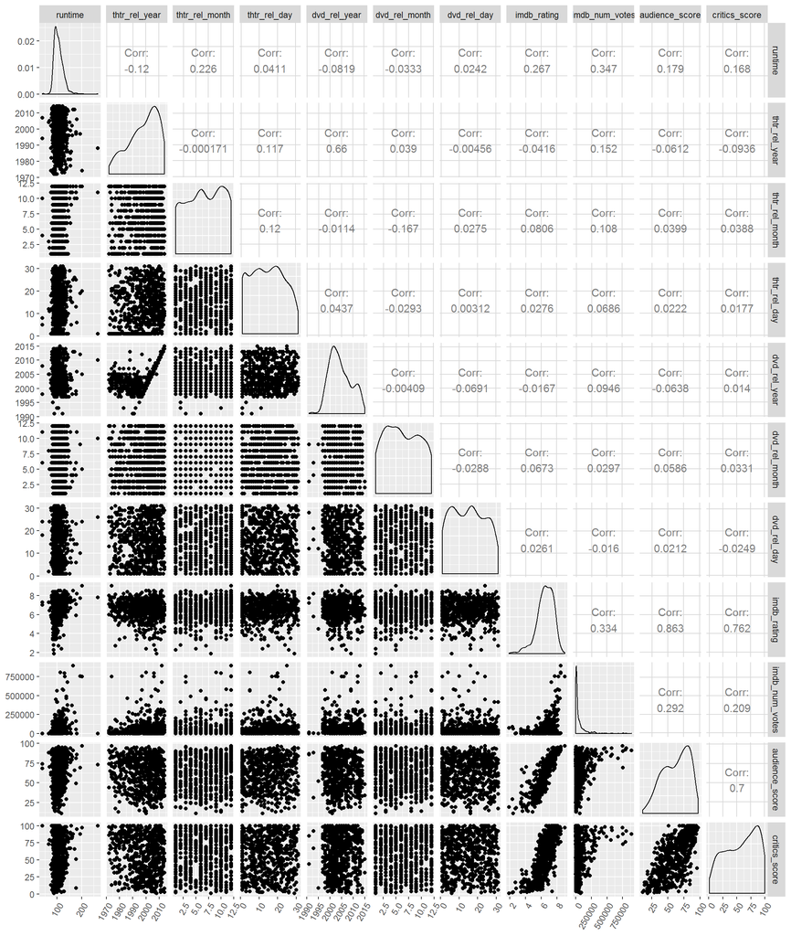

```r
# check correlarions for colinearity

keptnum<-select_if(kept, is.numeric)

p1<-ggpairs(keptnum)+
  theme(legend.position = "none", axis.text.x = element_text(angle = 60,hjust = 1))

p1
```

We’ll now look at how the critic’s score breaks out by some of the categorical variables.

This plot looks at the critic’s score by genre:

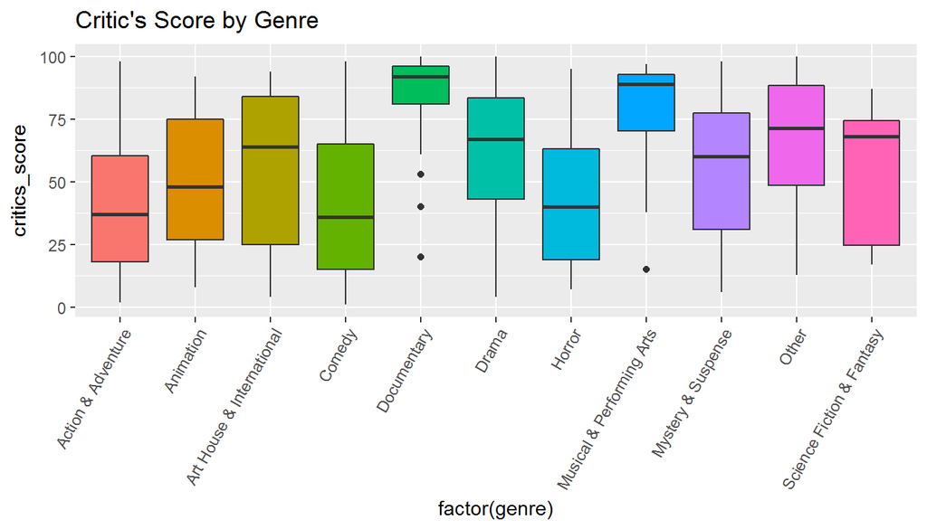

```r
p2<-ggplot(kept, aes(x=factor(genre), y=critics_score, fill=factor(genre)))+
  geom_boxplot()+
  theme(legend.position = "none", axis.text.x = element_text(angle = 60,hjust = 1))+
  ggtitle("Critic's Score by Genre")

p2
```

We see from this plot that documentaries and musicals have the highest average scores.

This plot looks at critic’s score by the film’s rating:

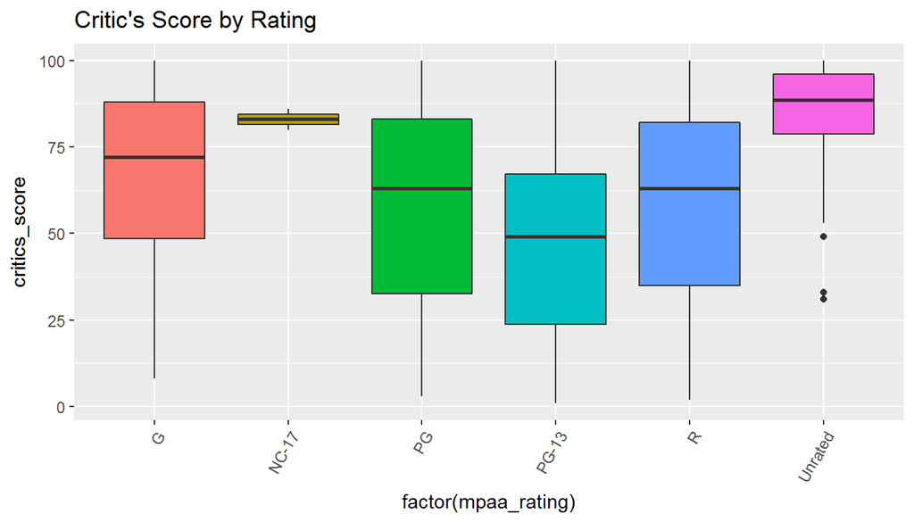

```r
p3<-ggplot(kept, aes(x=factor(mpaa_rating), y=critics_score, fill=factor(mpaa_rating)))+
  geom_boxplot()+
  theme(legend.position = "none", axis.text.x = element_text(angle = 60,hjust = 1))+
  ggtitle("Critic's Score by Rating")

p3
```

We see from this plot that unrated films have the highest scores on average, and the PG=13 films have the lowest average scores.

Now that we’ve taken a close look at the data set, it’s time to start building our model.

## Part 4: Modeling

First, I need to decide if I’m going to use the audience score or the IMDb rating in my model. Based on my EDA, these two independent variables are tightly correlated with each other, so I need to use one or the other in my model. To select which one, I will regress each against the critic’s score and select the on with the highest adjusted R squared.

```r
tm1<-lm(critics_score~imdb_rating, data=kept)

summary(tm1)
```

```
##
## Call:
## lm(formula = critics_score ~ imdb_rating, data = kept)
##
## Residuals:
##     Min      1Q  Median      3Q     Max
## -71.934 -12.778   2.994  14.018  43.220
##
## Coefficients:
##             Estimate Std. Error t value Pr(>|t|)
## (Intercept)  -72.778      4.454  -16.34   <2e-16 ***
## imdb_rating   20.096      0.676   29.73   <2e-16 ***
## ---
## Signif. codes:  0 '***' 0.001 '**' 0.01 '*' 0.05 '.' 0.1 ' ' 1
##
## Residual standard error: 18.39 on 640 degrees of freedom
## Multiple R-squared:   0.58,  Adjusted R-squared:  0.5793
## F-statistic: 883.7 on 1 and 640 DF,  p-value: < 2.2e-16
```

```r
tm2<-lm(critics_score~audience_score, data = kept)

summary(tm2)
```

```
##
## Call:
## lm(formula = critics_score ~ audience_score, data = kept)
##
## Residuals:
##     Min      1Q  Median      3Q     Max
## -69.181 -12.507   3.283  14.446  53.428
##
## Coefficients:
##                Estimate Std. Error t value Pr(>|t|)
## (Intercept)    -3.69020    2.60548  -1.416    0.157
## audience_score  0.98553    0.03972  24.814   <2e-16 ***
## ---
## Signif. codes:  0 '***' 0.001 '**' 0.01 '*' 0.05 '.' 0.1 ' ' 1
##
## Residual standard error: 20.26 on 640 degrees of freedom
## Multiple R-squared:  0.4903, Adjusted R-squared:  0.4895
## F-statistic: 615.8 on 1 and 640 DF,  p-value: < 2.2e-16
```

```r
kept$audience_score<-NULL
```

We see that the IMDb rating gives us a better adjusted R squared, so we will proceed using that variable.

I will also exclude the IMDb number of votes variable as it does not have anywhere close to a linear relationship with the dependant variable.

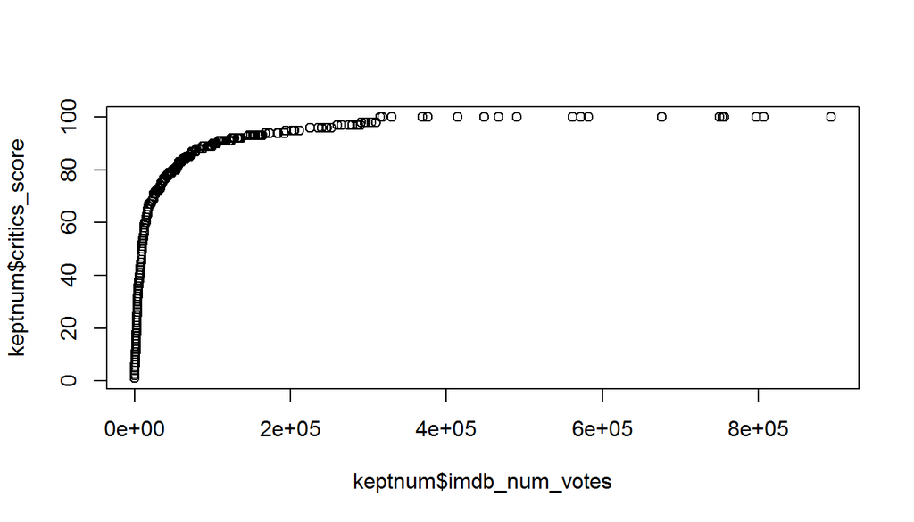

```r
qqplot(keptnum$imdb_num_votes, keptnum$critics_score)
```

```r
kept$imdb_num_votes<-NULL
```

I will now build my model using forward selection with adjusted R squared as the selection metric. I went with forward selection because it appears from the correlation matrix that I will have one or two variables explaining most of the variance. I will use the adjusted R squared method as I am more interested in predicting the dependant variable than understanding the significance of the various predictors.

This code will run a linear model for each of the independent variables against the critic’s score and a assemble a table with the independent variables ranked by adjusted R squared:

```r
# create df of independent variables

indvar<-kept[,-12]

# store variable names in vector

varlist <- names(indvar)

# function to run lms

models <- lapply(varlist, function(x) {
  lm(substitute(critics_score ~ i, list(i = as.name(x))), data = kept)
})

# grab adjusted r squared and output ranked in descending order

adjr2<-NULL
options(scipen=999)

for (i in 1:length(models)){
  adjr2[[i]]<-summary(models[[i]])$adj.r.squared
}

results1<-as.data.frame(cbind(varlist, adjr2))

results1<-results1 %>%
  arrange(desc(adjr2))

  kable(results1)
```

| varlist | adjr2 |
| --- | --- |
| imdb_rating | 0.579326383011481 |
| genre | 0.17688079074131 |
| title_type | 0.103128050049929 |
| mpaa_rating | 0.0877356832821321 |
| best_pic_nom | 0.0372607026419708 |
| runtime | 0.0266291166192368 |
| best_dir_win | 0.016565633213708 |
| best_pic_win | 0.0138215161396542 |
| top200_box | 0.0077788473561291 |
| thtr_rel_year | 0.00720442575180069 |
| best_actress_win | 0.00197766297611868 |
| best_actor_win | 0.000374067976429804 |
| dvd_rel_year | -0.00136534898092644 |
| thtr_rel_day | -0.00124973513369775 |
| dvd_rel_day | -0.000939943520600783 |
| dvd_rel_month | -0.000467026124332026 |
| thtr_rel_month | -0.0000580248749393331 |

We see that the IMDb rating is the variable that results in the highest adjusted R squared. This is not a surprise based on the correlation matrix from the EDA.

I continued this process eleven more times, adding an additional variable to the model each time until the adjusted R squared went down instead of up. The final selected model is as follows:

```r
final<-lm(critics_score ~ imdb_rating+mpaa_rating+title_type+
                genre+thtr_rel_year+dvd_rel_year+dvd_rel_day+
                best_dir_win+best_pic_nom+runtime+top200_box, data = kept)

summary(final)
```

```
##
## Call:
## lm(formula = critics_score ~ imdb_rating + mpaa_rating + title_type +
##     genre + thtr_rel_year + dvd_rel_year + dvd_rel_day + best_dir_win +
##     best_pic_nom + runtime + top200_box, data = kept)
##
## Residuals:
##     Min      1Q  Median      3Q     Max
## -56.459 -12.408   1.558  12.022  47.760
##
## Coefficients:
##                                  Estimate Std. Error t value
## (Intercept)                    -445.22470  330.57480  -1.347
## imdb_rating                      18.20562    0.79892  22.788
## mpaa_ratingNC-17                 12.54507   13.46502   0.932
## mpaa_ratingPG                    -3.84426    5.04803  -0.762
## mpaa_ratingPG-13                 -7.05494    5.27821  -1.337
## mpaa_ratingR                     -4.18520    5.07937  -0.824
## mpaa_ratingUnrated                4.99761    5.92453   0.844
## title_typeFeature Film          -16.21651    6.58580  -2.462
## title_typeTV Movie              -10.10046   10.39007  -0.972
## genreAnimation                    7.18355    7.01886   1.023
## genreArt House & International   -5.12312    5.57417  -0.919
## genreComedy                       4.20370    2.98421   1.409
## genreDocumentary                 -5.76300    7.09312  -0.812
## genreDrama                        8.54204    2.59305   3.294
## genreHorror                       3.64160    4.46535   0.816
## genreMusical & Performing Arts    5.51292    6.07726   0.907
## genreMystery & Suspense           5.04565    3.31203   1.523
## genreOther                        8.67371    5.07093   1.710
## genreScience Fiction & Fantasy    9.49666    6.66074   1.426
## thtr_rel_year                    -0.32589    0.09323  -3.495
## dvd_rel_year                      0.52838    0.20804   2.540
## dvd_rel_day                      -0.15409    0.07987  -1.929
## best_dir_winyes                   5.39476    2.92771   1.843
## best_pic_nomyes                   6.63977    4.09760   1.620
## runtime                          -0.07658    0.04235  -1.808
## top200_boxyes                     7.08992    4.80081   1.477
##                                            Pr(>|t|)
## (Intercept)                                0.178534
```

[output cut: 16 more lines]

```
## genreOther                                 0.087681 .
## genreScience Fiction & Fantasy             0.154442
## thtr_rel_year                              0.000507 ***
## dvd_rel_year                               0.011338 *
## dvd_rel_day                                0.054159 .
## best_dir_winyes                            0.065860 .
## best_pic_nomyes                            0.105657
## runtime                                    0.071030 .
## top200_boxyes                              0.140236
## ---
## Signif. codes:  0 '***' 0.001 '**' 0.01 '*' 0.05 '.' 0.1 ' ' 1
##
## Residual standard error: 17.66 on 616 degrees of freedom
## Multiple R-squared:  0.6273, Adjusted R-squared:  0.6122
## F-statistic: 41.48 on 25 and 616 DF,  p-value: < 0.00000000000000022
```

### Model Diagnostics

I’ll now check my model against the conditions for multiple linear regression. First we’ll make sure our residuals have a nearly normal distribution with a mean of 0.

```r
mean(final$residuals)
```

```
## [1] 0.0000000000000004296089
```

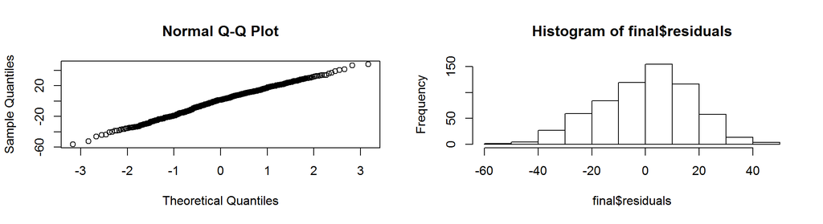

```r
par(mfrow=c(1,2))

qqnorm(final$residuals)
hist(final$residuals)
```

Next, we’ll check to make sure the numeric independent variables have a linear relationship with our dependant variable. We’ve already looked at this in the correlation matrix, but we’ll look again here:

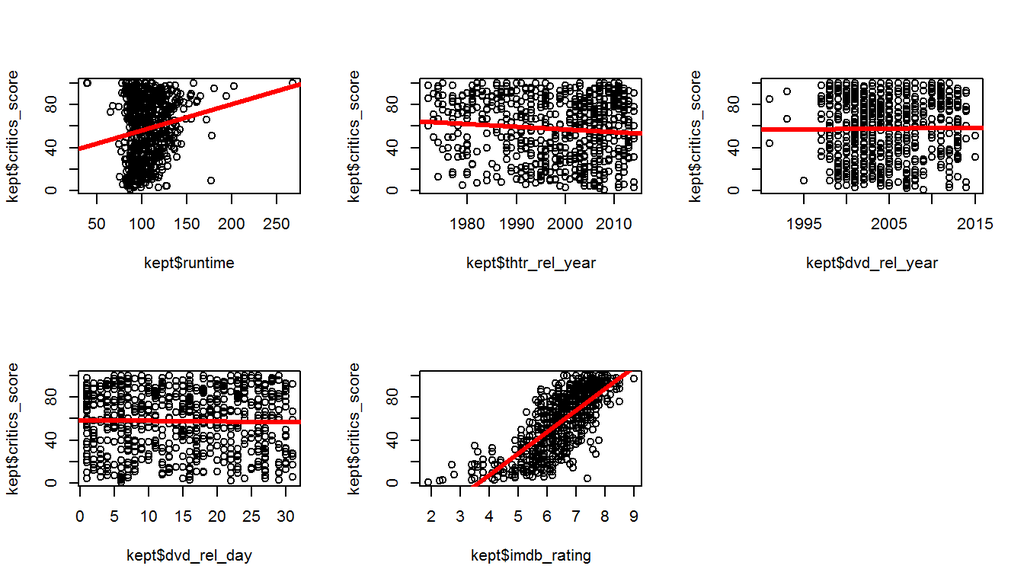

```r
par(mfrow=c(2,3))

plot(kept$critics_score~kept$runtime)
abline(lm(kept$critics_score~kept$runtime), col="red", lwd=3)

plot(kept$critics_score~kept$thtr_rel_year)
abline(lm(kept$critics_score~kept$thtr_rel_year), col="red", lwd=3)

plot(kept$critics_score~kept$dvd_rel_year)
abline(lm(kept$critics_score~kept$dvd_rel_year), col="red", lwd=3)

plot(kept$critics_score~kept$dvd_rel_day)
abline(lm(kept$critics_score~kept$dvd_rel_day), col="red", lwd=3)

plot(kept$critics_score~kept$imdb_rating)
abline(lm(kept$critics_score~kept$imdb_rating), col="red", lwd=3)
```

Aside from the IMDb rating, these relationships are pretty weak, but they still add a bit of additional information on our dependant variable based on the adjusted R squared method.

Next we’ll confirm the constant variability of the residuals by looking at a plot of the residuals vs. fitted values

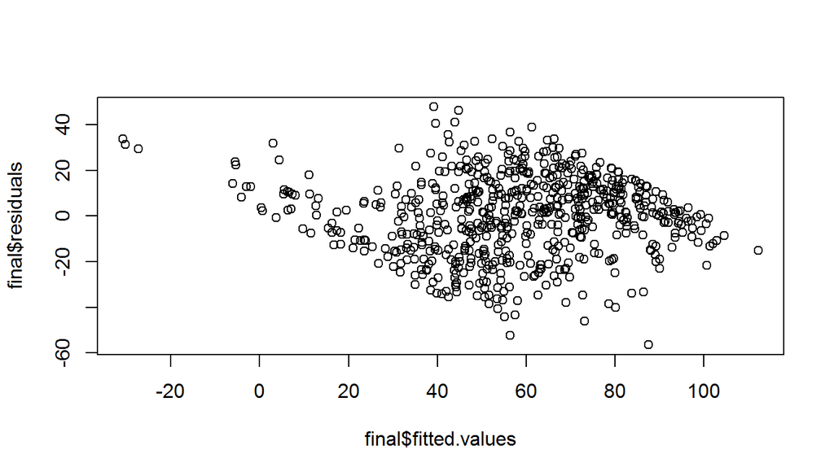

```r
plot(final$residuals~final$fitted.values)
```

Finally, we’ll check the independence of the residuals by plotting them against the order of data collection (index).

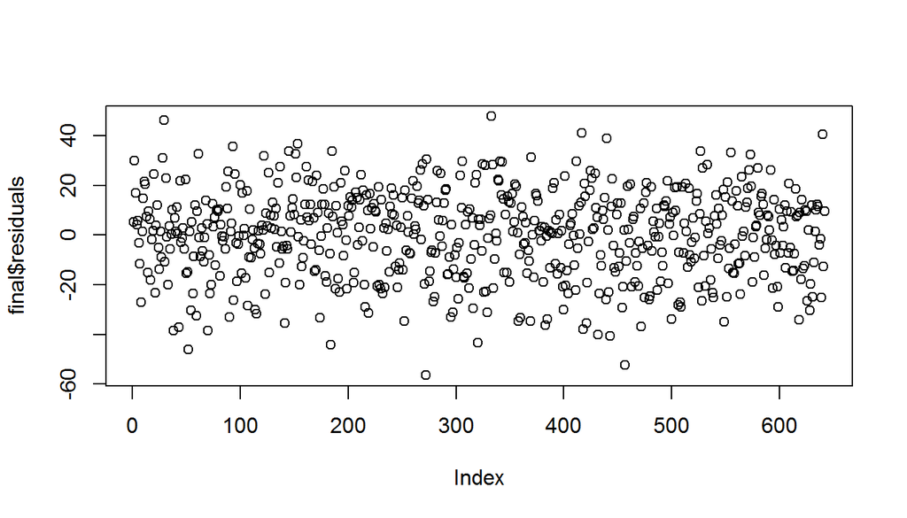

```r
plot(final$residuals)
```

## Part 5: Prediction

I’ll now use the predict function to predict the Rotten Tomatoes critic’s score for the following four films. I collected the data for these movies from the IMDb website (https://www.imdb.com/), the Rotten Tomatoes website (https://www.rottentomatoes.com/), and the Box Office Mojo website (http://www.boxofficemojo.com/).

- The Revenant
- La La Land
- Get Out
- The Space Between us

The first three films all have high critic’s scores, however the score for the Revenant seems a bit low for a film that won two Oscars. The Space Between Us has a very low critic’s score - especially compared to the audience score. I deliberately selected some extreme values to test the predictive powers of the model. I expect I may lose a few points on the accuracy as a result, but let’s see what happens…..

The following code will predict the critics score for the films mentioned above and return a table with the predicted value, upper and lower bounds for the uncertainty based on a 95% confidence interval, and the actual critic’s score for the film:

```r
# Predict

# The Revenant
# La La Land
# Get Out
# The Space Between Us

newdata<-read.csv("newdata.csv")

preds<-as.data.frame(predict(final, newdata=newdata, interval="confidence", level=.95))

Title<-c("The Revenant", "La La Land", "Get Out", "The Space Between Us")

preds<-as.data.frame(cbind(Title, preds))

names(preds)<-c("Title", "Predicted Score", "Lower 95%", "Upper 95%")

preds$ActualScore<-newdata$critics_score

kable(preds)
```

| Title | Predicted Score | Lower 95% | Upper 95% | ActualScore |
| --- | --- | --- | --- | --- |
| The Revenant | 100.81667 | 88.02182 | 113.61152 | 80 |
| La La Land | 100.84632 | 83.57071 | 118.12194 | 92 |
| Get Out | 90.23478 | 76.86383 | 103.60572 | 99 |
| The Space Between Us | 52.23910 | 46.93896 | 57.53925 | 16 |

## Part 6: Conclusion

This analysis has shown me that there is a strong connection between film critics opinions and the public at large. From the data set provided, the variable representing the public’s opionion (IMDb score) accounted for the vast majority of the variance in the dependant variable (Rotten Tomatoe’s critits score) explained by my model. There can, however, be significant divergence of opinion, as evidenced by the prediction for “The Space Between Us”. I think it would be interesting to investigate additional data sources for critical reviews to include in subsequent models.

All of the r code for this analysis can be found here:

https://github.com/lecroc/Linear-Regression-and-Modeling